# Predict Bike Sharing Demand with AutoGluon

# Step 1: Download the Kaggle dataset using the kaggle python library

### Install packages

```python
!pip install -U pip
!pip install -U setuptools wheel
!pip install -U "mxnet<2.0.0" bokeh==2.0.1
!pip install autogluon --no-cache-dir
# Without --no-cache-dir, smaller aws instances may have trouble installing
```

[output not shown]

[output cut: 65 more lines]

[output not shown]

### Setup Kaggle API Key

```python
import os
import json

if not os.path.exists(os.path.expanduser("~/.kaggle/kaggle.json")):
    print("Please upload your kaggle.json to ~/.kaggle/ before continuing.")
else:
    print("Kaggle API token found.")
```

```
Kaggle API token found.
```

```python
!echo ".kaggle/" >> .gitignore
```

```python
# Set safe user path
kaggle_dir = os.path.expanduser("~/.kaggle")
kaggle_path = os.path.join(kaggle_dir, "kaggle.json")

# Optional: Insert your username and key here if needed
# kaggle_username = "your_username"
# kaggle_key = "your_key"

# Create directory and file only if missing
if not os.path.exists(kaggle_path):
    os.makedirs(kaggle_dir, exist_ok=True)
    with open(kaggle_path, "w") as f:
        f.write(json.dumps({"username": "FILL_IN_USERNAME", "key": "FILL_IN_KEY"}))
    os.chmod(kaggle_path, 0o600)
    print("kaggle.json created at ~/.kaggle/")
else:
    print("kaggle.json already exists.")
```

```
kaggle.json already exists.
```

### Download and explore dataset

```python
# Download the dataset, it will be in a .zip file so you'll need to unzip it as well.
!kaggle competitions download -c bike-sharing-demand
# If you already downloaded it you can use the -o command to overwrite the file
!unzip -o bike-sharing-demand.zip
```

```
Downloading bike-sharing-demand.zip to /home/sagemaker-user/cd0385-project-starter/project
Archive:  bike-sharing-demand.zip
  inflating: sampleSubmission.csv
  inflating: test.csv
  inflating: train.csv
```

```python
import pandas as pd
from autogluon.tabular import TabularPredictor
```

```python
# Create the train dataset in pandas by reading the csv
# Set the parsing of the datetime column so you can use some of the `dt` features in pandas later
train = pd.read_csv("train.csv", parse_dates=["datetime"])
train.head()
```

|  | datetime | season | holiday | workingday | weather | temp | atemp | humidity | windspeed | casual | registered | count |
| --- | --- | --- | --- | --- | --- | --- | --- | --- | --- | --- | --- | --- |
| 0 | 2011-01-01 00:00:00 | 1 | 0 | 0 | 1 | 9.84 | 14.395 | 81 | 0.0 | 3 | 13 | 16 |
| 1 | 2011-01-01 01:00:00 | 1 | 0 | 0 | 1 | 9.02 | 13.635 | 80 | 0.0 | 8 | 32 | 40 |
| 2 | 2011-01-01 02:00:00 | 1 | 0 | 0 | 1 | 9.02 | 13.635 | 80 | 0.0 | 5 | 27 | 32 |
| 3 | 2011-01-01 03:00:00 | 1 | 0 | 0 | 1 | 9.84 | 14.395 | 75 | 0.0 | 3 | 10 | 13 |
| 4 | 2011-01-01 04:00:00 | 1 | 0 | 0 | 1 | 9.84 | 14.395 | 75 | 0.0 | 0 | 1 | 1 |

```python
# Simple output of the train dataset to view some of the min/max/varition of the dataset features.
```

[output not shown]

```python
# Create the test pandas dataframe in pandas by reading the csv, remember to parse the datetime!
test = pd.read_csv("test.csv", parse_dates=["datetime"])
test.head()
```

|  | datetime | season | holiday | workingday | weather | temp | atemp | humidity | windspeed |
| --- | --- | --- | --- | --- | --- | --- | --- | --- | --- |
| 0 | 2011-01-20 00:00:00 | 1 | 0 | 1 | 1 | 10.66 | 11.365 | 56 | 26.0027 |
| 1 | 2011-01-20 01:00:00 | 1 | 0 | 1 | 1 | 10.66 | 13.635 | 56 | 0.0000 |
| 2 | 2011-01-20 02:00:00 | 1 | 0 | 1 | 1 | 10.66 | 13.635 | 56 | 0.0000 |
| 3 | 2011-01-20 03:00:00 | 1 | 0 | 1 | 1 | 10.66 | 12.880 | 56 | 11.0014 |
| 4 | 2011-01-20 04:00:00 | 1 | 0 | 1 | 1 | 10.66 | 12.880 | 56 | 11.0014 |

```python
# Same thing as train and test dataset
submission = pd.read_csv("sampleSubmission.csv")
submission.head()
```

|  | datetime | count |
| --- | --- | --- |
| 0 | 2011-01-20 00:00:00 | 0 |
| 1 | 2011-01-20 01:00:00 | 0 |
| 2 | 2011-01-20 02:00:00 | 0 |
| 3 | 2011-01-20 03:00:00 | 0 |
| 4 | 2011-01-20 04:00:00 | 0 |

## Step 3: Train a model using AutoGluon’s Tabular Prediction

Requirements:

- We are prediting `count`, so it is the label we are setting.
- Ignore `casual` and `registered` columns as they are also not present in the test dataset.
- Use the `root_mean_squared_error` as the metric to use for evaluation.
- Set a time limit of 10 minutes (600 seconds).
- Use the preset `best_quality` to focus on creating the best model.

```python
predictor = TabularPredictor(label="count", eval_metric="root_mean_squared_error").fit(train.drop(columns=["casual", "registered"]), time_limit=600, presets="best_quality")
```

[output not shown]

[output cut: 36 more lines]

[output not shown]

[output not shown]

[output not shown]

[output not shown]

[output not shown]

[output not shown]

[output not shown]

[output not shown]

```
(_dystack pid=1002) 	-73.6831	 = Validation score   (-root_mean_squared_error)
(_dystack pid=1002) 	34.18s	 = Training   runtime
(_dystack pid=1002) 	1.79s	 = Validation runtime
(_dystack pid=1002) Fitting model: LightGBM_BAG_L2 ... Training model for up to 5.17s of the 5.14s of remaining time.
(_dystack pid=1002) 	Fitting 8 child models (S1F1 - S1F8) | Fitting with ParallelLocalFoldFittingStrategy (2 workers, per: cpus=1, gpus=0, memory=0.62%)
(_ray_fit pid=2002) 	Ran out of time, early stopping on iteration 361. Best iteration is:
(_ray_fit pid=2002) 	[204]	valid_set's rmse: 63.4345
(_ray_fit pid=2066) 	Ran out of time, early stopping on iteration 326. Best iteration is: [repeated 2x across cluster]
(_ray_fit pid=2066) 	[225]	valid_set's rmse: 69.1472 [repeated 2x across cluster]
(_ray_fit pid=2157) 	Ran out of time, early stopping on iteration 394. Best iteration is: [repeated 2x across cluster]
(_ray_fit pid=2157) 	[141]	valid_set's rmse: 70.4637 [repeated 2x across cluster]
(_ray_fit pid=2223) 	Ran out of time, early stopping on iteration 350. Best iteration is: [repeated 2x across cluster]
(_ray_fit pid=2223) 	[255]	valid_set's rmse: 69.4092 [repeated 2x across cluster]
(_dystack pid=1002) 	-67.7201	 = Validation score   (-root_mean_squared_error)
(_dystack pid=1002) 	21.78s	 = Training   runtime
(_dystack pid=1002) 	0.14s	 = Validation runtime
(_dystack pid=1002) Fitting model: WeightedEnsemble_L3 ... Training model for up to 144.40s of the -20.18s of remaining time.
(_dystack pid=1002) 	Ensemble Weights: {'LightGBM_BAG_L2': 1.0}
(_dystack pid=1002) 	-67.7201	 = Validation score   (-root_mean_squared_error)
(_dystack pid=1002) 	0.03s	 = Training   runtime
(_dystack pid=1002) 	0.0s	 = Validation runtime
(_dystack pid=1002) AutoGluon training complete, total runtime = 164.71s ... Best model: WeightedEnsemble_L3 | Estimated inference throughput: 112.2 rows/s (1210 batch size)
(_dystack pid=1002) TabularPredictor saved. To load, use: predictor = TabularPredictor.load("/home/sagemaker-user/cd0385-project-starter/project/AutogluonModels/ag-20250604_160741/ds_sub_fit/sub_fit_ho")
(_dystack pid=1002) Deleting DyStack predictor artifacts (clean_up_fits=True) ...
(_ray_fit pid=2221) 	Ran out of time, early stopping on iteration 391. Best iteration is:
(_ray_fit pid=2221) 	[126]	valid_set's rmse: 66.993
Leaderboard on holdout data (DyStack):
                   model  score_holdout   score_val              eval_metric  pred_time_test  pred_time_val    fit_time  pred_time_test_marginal  pred_time_val_marginal  fit_time_marginal  stack_level  can_infer  fit_order
0        LightGBM_BAG_L2     -69.842341  -67.720101  root_mean_squared_error        8.754202      10.867769  110.620184                 0.139716                0.142322          21.776779            2       True          7
1    WeightedEnsemble_L3     -69.842341  -67.720101  root_mean_squared_error        8.755749      10.868559  110.650618                 0.001547                0.000790           0.030434            3       True          8
2      LightGBMXT_BAG_L2     -72.792720  -73.683056  root_mean_squared_error       10.123184      12.512268  123.020124                 1.508698                1.786821          34.176719            2       True          6
3  KNeighborsDist_BAG_L1     -92.031272  -89.946854  root_mean_squared_error        0.082937       0.047832    0.017125                 0.082937                0.047832           0.017125            1       True          2
4    WeightedEnsemble_L2     -92.031272  -89.946854  root_mean_squared_error        0.084689       0.048641    0.037854                 0.001751                0.000809           0.020729            2       True          5
5  KNeighborsUnif_BAG_L1    -109.161488 -107.445008  root_mean_squared_error        0.070630       0.045217    0.020483                 0.070630                0.045217           0.020483            1       True          1
6        LightGBM_BAG_L1    -130.706758 -131.849580  root_mean_squared_error        0.910962       0.980608   27.473221                 0.910962                0.980608          27.473221            1       True          4
7      LightGBMXT_BAG_L1    -131.068281 -131.975832  root_mean_squared_error        7.549957       9.651790   61.332576                 7.549957                9.651790          61.332576            1       True          3
	1	 = Optimal   num_stack_levels (Stacked Overfitting Occurred: False)
	183s	 = DyStack   runtime |	417s	 = Remaining runtime
Starting main fit with num_stack_levels=1.
	For future fit calls on this dataset, you can skip DyStack to save time: `predictor.fit(..., dynamic_stacking=False, num_stack_levels=1)`
```

[output cut: 108 more lines]

```
	-54.9726	 = Validation score   (-root_mean_squared_error)
	26.29s	 = Training   runtime
	0.32s	 = Validation runtime
Fitting model: RandomForestMSE_BAG_L2 ... Training model for up to 23.43s of the 23.38s of remaining time.
I0000 00:00:1749053838.686385    1079 chttp2_transport.cc:1182] ipv4:169.255.255.2:36527: Got goaway [2] err=UNAVAILABLE:GOAWAY received; Error code: 2; Debug Text: Cancelling all calls {grpc_status:14, http2_error:2, created_time:"2025-06-04T16:17:18.686381734+00:00"}
	-53.2851	 = Validation score   (-root_mean_squared_error)
	39.72s	 = Training   runtime
	0.67s	 = Validation runtime
Fitting model: WeightedEnsemble_L3 ... Training model for up to 360.00s of the -17.68s of remaining time.
	Ensemble Weights: {'RandomForestMSE_BAG_L2': 0.72, 'LightGBM_BAG_L2': 0.24, 'LightGBMXT_BAG_L2': 0.04}
	-52.9856	 = Validation score   (-root_mean_squared_error)
	0.03s	 = Training   runtime
	0.0s	 = Validation runtime
AutoGluon training complete, total runtime = 435.03s ... Best model: WeightedEnsemble_L3 | Estimated inference throughput: 92.4 rows/s (1361 batch size)
TabularPredictor saved. To load, use: predictor = TabularPredictor.load("/home/sagemaker-user/cd0385-project-starter/project/AutogluonModels/ag-20250604_160741")
```

### Review AutoGluon's training run with ranking of models that did the best.

```python
predictor.fit_summary()
```

```
*** Summary of fit() ***
Estimated performance of each model:
                     model   score_val              eval_metric  pred_time_val    fit_time  pred_time_val_marginal  fit_time_marginal  stack_level  can_infer  fit_order
0      WeightedEnsemble_L3  -52.985580  root_mean_squared_error      16.425453  403.530884                0.000610           0.034259            3       True         13
1   RandomForestMSE_BAG_L2  -53.285113  root_mean_squared_error      12.232558  324.081925                0.671589          39.720490            2       True         12
2          LightGBM_BAG_L2  -54.972554  root_mean_squared_error      11.876580  310.654542                0.315611          26.293107            2       True         11
3        LightGBMXT_BAG_L2  -60.429638  root_mean_squared_error      15.437642  337.483027                3.876673          53.121593            2       True         10
4    KNeighborsDist_BAG_L1  -84.125061  root_mean_squared_error       0.036325    0.031367                0.036325           0.031367            1       True          2
5      WeightedEnsemble_L2  -84.125061  root_mean_squared_error       0.037200    0.068019                0.000875           0.036652            2       True          9
6    KNeighborsUnif_BAG_L1 -101.546199  root_mean_squared_error       0.036100    0.035460                0.036100           0.035460            1       True          1
7   RandomForestMSE_BAG_L1 -116.548359  root_mean_squared_error       0.591901   14.688412                0.591901          14.688412            1       True          5
8     ExtraTreesMSE_BAG_L1 -124.600676  root_mean_squared_error       0.603216    7.296069                0.603216           7.296069            1       True          7
9          CatBoost_BAG_L1 -130.719641  root_mean_squared_error       0.145158  135.337202                0.145158         135.337202            1       True          6
10         LightGBM_BAG_L1 -131.054162  root_mean_squared_error       1.540532   28.528448                1.540532          28.528448            1       True          4
11       LightGBMXT_BAG_L1 -131.460909  root_mean_squared_error       8.181927   59.411273                8.181927          59.411273            1       True          3
12  NeuralNetFastAI_BAG_L1 -142.835346  root_mean_squared_error       0.425810   39.033204                0.425810          39.033204            1       True          8
Number of models trained: 13
Types of models trained:
{'StackerEnsembleModel_KNN', 'StackerEnsembleModel_CatBoost', 'StackerEnsembleModel_RF', 'StackerEnsembleModel_XT', 'WeightedEnsembleModel', 'StackerEnsembleModel_NNFastAiTabular', 'StackerEnsembleModel_LGB'}
Bagging used: True  (with 8 folds)
Multi-layer stack-ensembling used: True  (with 3 levels)
Feature Metadata (Processed):
(raw dtype, special dtypes):
('float', [])                : 3 | ['temp', 'atemp', 'windspeed']
('int', [])                  : 3 | ['season', 'weather', 'humidity']
('int', ['bool'])            : 2 | ['holiday', 'workingday']
('int', ['datetime_as_int']) : 5 | ['datetime', 'datetime.year', 'datetime.month', 'datetime.day', 'datetime.dayofweek']
*** End of fit() summary ***
```

```
{'model_types': {'KNeighborsUnif_BAG_L1': 'StackerEnsembleModel_KNN',
  'KNeighborsDist_BAG_L1': 'StackerEnsembleModel_KNN',
  'LightGBMXT_BAG_L1': 'StackerEnsembleModel_LGB',
  'LightGBM_BAG_L1': 'StackerEnsembleModel_LGB',
  'RandomForestMSE_BAG_L1': 'StackerEnsembleModel_RF',
  'CatBoost_BAG_L1': 'StackerEnsembleModel_CatBoost',
  'ExtraTreesMSE_BAG_L1': 'StackerEnsembleModel_XT',
  'NeuralNetFastAI_BAG_L1': 'StackerEnsembleModel_NNFastAiTabular',
  'WeightedEnsemble_L2': 'WeightedEnsembleModel',
  'LightGBMXT_BAG_L2': 'StackerEnsembleModel_LGB',
  'LightGBM_BAG_L2': 'StackerEnsembleModel_LGB',
  'RandomForestMSE_BAG_L2': 'StackerEnsembleModel_RF',
  'WeightedEnsemble_L3': 'WeightedEnsembleModel'},
 'model_performance': {'KNeighborsUnif_BAG_L1': -101.54619908446061,
  'KNeighborsDist_BAG_L1': -84.12506123181602,
  'LightGBMXT_BAG_L1': -131.46090891834504,
  'LightGBM_BAG_L1': -131.054161598899,
  'RandomForestMSE_BAG_L1': -116.54835939455667,
  'CatBoost_BAG_L1': -130.71964128092387,
  'ExtraTreesMSE_BAG_L1': -124.60067564699747,
  'NeuralNetFastAI_BAG_L1': -142.83534621375162,
  'WeightedEnsemble_L2': -84.12506123181602,
  'LightGBMXT_BAG_L2': -60.42963786969469,
  'LightGBM_BAG_L2': -54.972554417247615,
  'RandomForestMSE_BAG_L2': -53.285112933800015,
  'WeightedEnsemble_L3': -52.985579685775356},
 'model_best': 'WeightedEnsemble_L3',
 'model_paths': {'KNeighborsUnif_BAG_L1': ['KNeighborsUnif_BAG_L1'],
  'KNeighborsDist_BAG_L1': ['KNeighborsDist_BAG_L1'],
  'LightGBMXT_BAG_L1': ['LightGBMXT_BAG_L1'],
  'LightGBM_BAG_L1': ['LightGBM_BAG_L1'],
  'RandomForestMSE_BAG_L1': ['RandomForestMSE_BAG_L1'],
  'CatBoost_BAG_L1': ['CatBoost_BAG_L1'],
  'ExtraTreesMSE_BAG_L1': ['ExtraTreesMSE_BAG_L1'],
  'NeuralNetFastAI_BAG_L1': ['NeuralNetFastAI_BAG_L1'],
  'WeightedEnsemble_L2': ['WeightedEnsemble_L2'],
  'LightGBMXT_BAG_L2': ['LightGBMXT_BAG_L2'],
  'LightGBM_BAG_L2': ['LightGBM_BAG_L2'],
  'RandomForestMSE_BAG_L2': ['RandomForestMSE_BAG_L2'],
  'WeightedEnsemble_L3': ['WeightedEnsemble_L3']},
```

[output cut: 127 more lines]

```

     stack_level  can_infer  fit_order
 0             3       True         13
 1             2       True         12
 2             2       True         11
 3             2       True         10
 4             1       True          2
 5             2       True          9
 6             1       True          1
 7             1       True          5
 8             1       True          7
 9             1       True          6
 10            1       True          4
 11            1       True          3
 12            1       True          8  }
```

### Create predictions from test dataset

```python
predictions = predictor.predict(test)
predictions.head()
```

```
0    22.836102
1    42.723415
2    46.233505
3    48.996872
4    51.524574
Name: count, dtype: float32
```

#### NOTE: Kaggle will reject the submission if we don't set everything to be > 0.

```python
# Describe the `predictions` series to see if there are any negative values
predictions.describe()
```

```
count    6493.000000
mean      100.730186
std        89.886978
min         3.043915
25%        20.274658
50%        64.065826
75%       166.959854
max       368.980835
Name: count, dtype: float64
```

```python
# How many negative values do we have?
(predictions < 0).sum()
```

```
0
```

```python
# Set them to zero
predictions = predictions.clip(lower=0)
```

### Set predictions to submission dataframe, save, and submit

```python
submission["count"] = predictions
submission.to_csv("submission.csv", index=False)
```

```python
!kaggle competitions submit -c bike-sharing-demand -f submission.csv -m "first raw submission"
```

```
Successfully submitted to Bike Sharing Demand
```

#### View submission via the command line or in the web browser under the competition's page - `My Submissions`

```python
!kaggle competitions submissions -c bike-sharing-demand | tail -n +1 | head -n 6
```

```
fileName        date                        description           status                     publicScore  privateScore
--------------  --------------------------  --------------------  -------------------------  -----------  ------------
submission.csv  2025-06-04 16:25:00.120000  first raw submission  SubmissionStatus.COMPLETE  1.79927      1.79927
```

#### Initial score of `1.79927`

## Step 4: Exploratory Data Analysis and Creating an additional feature

- Any additional feature will do, but a great suggestion would be to separate out the datetime into hour, day, or month parts.

```
array([[<Axes: title={'center': 'datetime'}>,
        <Axes: title={'center': 'season'}>,
        <Axes: title={'center': 'holiday'}>],
       [<Axes: title={'center': 'workingday'}>,
        <Axes: title={'center': 'weather'}>,
        <Axes: title={'center': 'temp'}>],
       [<Axes: title={'center': 'atemp'}>,
        <Axes: title={'center': 'humidity'}>,
        <Axes: title={'center': 'windspeed'}>],
       [<Axes: title={'center': 'casual'}>,
        <Axes: title={'center': 'registered'}>,
        <Axes: title={'center': 'count'}>]], dtype=object)
```

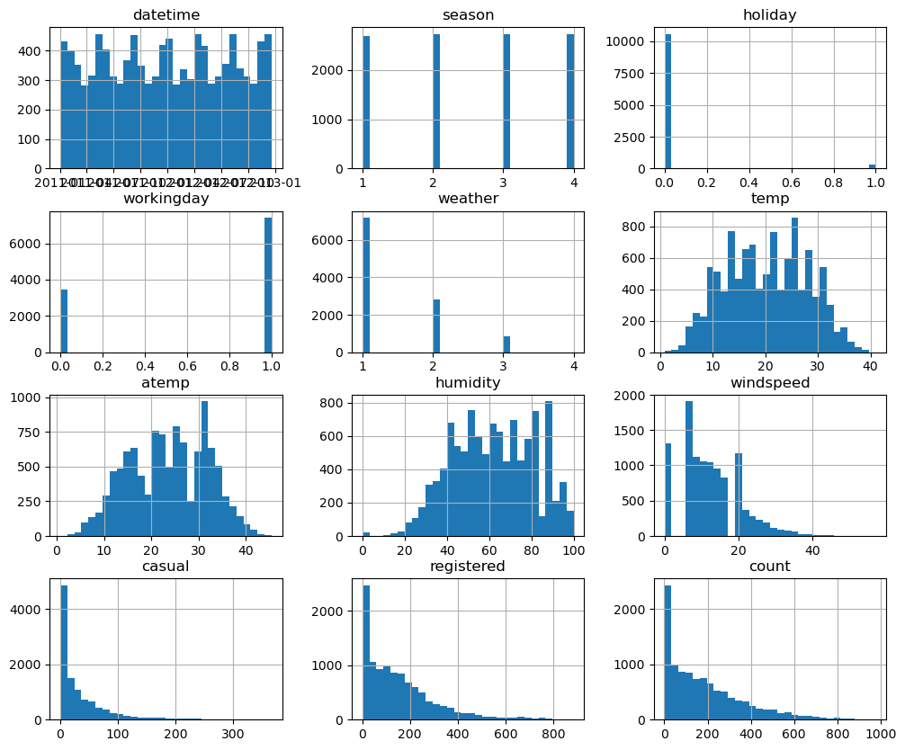

```python
# Create a histogram of all features to show the distribution of each one relative to the data. This is part of the exploritory data analysis
train.hist(figsize=(12, 10), bins=30)
```

```python
#check mins/maxes/distribution
train.describe()
```

|  | datetime | season | holiday | workingday | weather | temp | atemp | humidity | windspeed | casual | registered | count |
| --- | --- | --- | --- | --- | --- | --- | --- | --- | --- | --- | --- | --- |
| count | 10886 | 10886.000000 | 10886.000000 | 10886.000000 | 10886.000000 | 10886.00000 | 10886.000000 | 10886.000000 | 10886.000000 | 10886.000000 | 10886.000000 | 10886.000000 |
| mean | 2011-12-27 05:56:22.399411968 | 2.506614 | 0.028569 | 0.680875 | 1.418427 | 20.23086 | 23.655084 | 61.886460 | 12.799395 | 36.021955 | 155.552177 | 191.574132 |
| min | 2011-01-01 00:00:00 | 1.000000 | 0.000000 | 0.000000 | 1.000000 | 0.82000 | 0.760000 | 0.000000 | 0.000000 | 0.000000 | 0.000000 | 1.000000 |
| 25% | 2011-07-02 07:15:00 | 2.000000 | 0.000000 | 0.000000 | 1.000000 | 13.94000 | 16.665000 | 47.000000 | 7.001500 | 4.000000 | 36.000000 | 42.000000 |
| 50% | 2012-01-01 20:30:00 | 3.000000 | 0.000000 | 1.000000 | 1.000000 | 20.50000 | 24.240000 | 62.000000 | 12.998000 | 17.000000 | 118.000000 | 145.000000 |
| 75% | 2012-07-01 12:45:00 | 4.000000 | 0.000000 | 1.000000 | 2.000000 | 26.24000 | 31.060000 | 77.000000 | 16.997900 | 49.000000 | 222.000000 | 284.000000 |
| max | 2012-12-19 23:00:00 | 4.000000 | 1.000000 | 1.000000 | 4.000000 | 41.00000 | 45.455000 | 100.000000 | 56.996900 | 367.000000 | 886.000000 | 977.000000 |
| std | NaN | 1.116174 | 0.166599 | 0.466159 | 0.633839 | 7.79159 | 8.474601 | 19.245033 | 8.164537 | 49.960477 | 151.039033 | 181.144454 |

```python
# check missing values
train.isnull().sum()
```

```
datetime      0
season        0
holiday       0
workingday    0
weather       0
temp          0
atemp         0
humidity      0
windspeed     0
casual        0
registered    0
count         0
dtype: int64
```

```python
# create a new feature
# hours
train["hour"] = train["datetime"].dt.hour
test["hour"] = test["datetime"].dt.hour
# day of week
train["dayofweek"] = train["datetime"].dt.dayofweek
test["dayofweek"] = test["datetime"].dt.dayofweek
```

## Make category types for these so models know they are not just numbers

- AutoGluon originally sees these as ints, but in reality they are int representations of a category.
- Setting the dtype to category will classify these as categories in AutoGluon.

```python
for col in ["season", "weather", "hour", "dayofweek"]:
    train[col] = train[col].astype("category")
    test[col] = test[col].astype("category")
```

```python
# View are new feature
train.head()
```

|  | datetime | season | holiday | workingday | weather | temp | atemp | humidity | windspeed | casual | registered | count | hour | dayofweek |
| --- | --- | --- | --- | --- | --- | --- | --- | --- | --- | --- | --- | --- | --- | --- |
| 0 | 2011-01-01 00:00:00 | 1 | 0 | 0 | 1 | 9.84 | 14.395 | 81 | 0.0 | 3 | 13 | 16 | 0 | 5 |
| 1 | 2011-01-01 01:00:00 | 1 | 0 | 0 | 1 | 9.02 | 13.635 | 80 | 0.0 | 8 | 32 | 40 | 1 | 5 |
| 2 | 2011-01-01 02:00:00 | 1 | 0 | 0 | 1 | 9.02 | 13.635 | 80 | 0.0 | 5 | 27 | 32 | 2 | 5 |
| 3 | 2011-01-01 03:00:00 | 1 | 0 | 0 | 1 | 9.84 | 14.395 | 75 | 0.0 | 3 | 10 | 13 | 3 | 5 |
| 4 | 2011-01-01 04:00:00 | 1 | 0 | 0 | 1 | 9.84 | 14.395 | 75 | 0.0 | 0 | 1 | 1 | 4 | 5 |

```
array([[<Axes: title={'center': 'datetime'}>,
        <Axes: title={'center': 'holiday'}>,
        <Axes: title={'center': 'workingday'}>],
       [<Axes: title={'center': 'temp'}>,
        <Axes: title={'center': 'atemp'}>,
        <Axes: title={'center': 'humidity'}>],
       [<Axes: title={'center': 'windspeed'}>,
        <Axes: title={'center': 'casual'}>,
        <Axes: title={'center': 'registered'}>],
       [<Axes: title={'center': 'count'}>, <Axes: >, <Axes: >]],
      dtype=object)
```

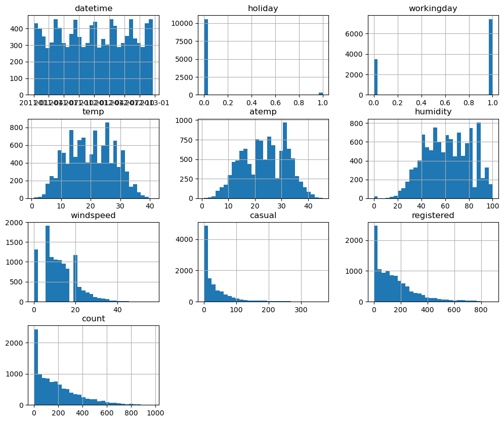

```python
# View histogram of all features again now with the hour feature
train.hist(figsize=(12, 10), bins=30)
# hours won't show because it's categorical not int anymore
```

## Step 5: Rerun the model with the same settings as before, just with more features

```python
predictor_new_features = TabularPredictor(label="count", eval_metric="root_mean_squared_error").fit(train.drop(columns=["casual", "registered"]), time_limit=600, presets="best_quality")
```

```
No path specified. Models will be saved in: "AutogluonModels/ag-20250604_163658"
Verbosity: 2 (Standard Logging)
=================== System Info ===================
AutoGluon Version:  1.2
Python Version:     3.12.9
Operating System:   Linux
Platform Machine:   x86_64
Platform Version:   #1 SMP Tue May 6 04:10:50 UTC 2025
CPU Count:          2
Memory Avail:       1.15 GB / 3.76 GB (30.7%)
Disk Space Avail:   3.87 GB / 4.99 GB (77.6%)
	WARNING: Available disk space is low and there is a risk that AutoGluon will run out of disk during fit, causing an exception.
	We recommend a minimum available disk space of 10 GB, and large datasets may require more.
===================================================
Presets specified: ['best_quality']
Setting dynamic_stacking from 'auto' to True. Reason: Enable dynamic_stacking when use_bag_holdout is disabled. (use_bag_holdout=False)
Stack configuration (auto_stack=True): num_stack_levels=1, num_bag_folds=8, num_bag_sets=1
DyStack is enabled (dynamic_stacking=True). AutoGluon will try to determine whether the input data is affected by stacked overfitting and enable or disable stacking as a consequence.
	This is used to identify the optimal `num_stack_levels` value. Copies of AutoGluon will be fit on subsets of the data. Then holdout validation data is used to detect stacked overfitting.
	Running DyStack for up to 150s of the 600s of remaining time (25%).
		Context path: "/home/sagemaker-user/cd0385-project-starter/project/AutogluonModels/ag-20250604_163658/ds_sub_fit/sub_fit_ho"
Leaderboard on holdout data (DyStack):
                    model  score_holdout   score_val              eval_metric  pred_time_test  pred_time_val    fit_time  pred_time_test_marginal  pred_time_val_marginal  fit_time_marginal  stack_level  can_infer  fit_order
0         LightGBM_BAG_L2     -31.697209  -33.155762  root_mean_squared_error        7.794670       7.703353  111.113715                 0.149367                0.182370          23.399586            2       True          8
1     WeightedEnsemble_L3     -31.808845  -32.589212  root_mean_squared_error        8.218722       8.256137  136.145804                 0.002693                0.000824           0.029884            3       True          9
2       LightGBMXT_BAG_L2     -32.242840  -32.981691  root_mean_squared_error        8.066663       8.072942  112.716334                 0.421360                0.551959          25.002206            2       True          7
3     WeightedEnsemble_L2     -33.778165  -34.200690  root_mean_squared_error        7.608470       7.480799   87.751869                 0.003590                0.002749           0.053864            2       True          6
4       LightGBMXT_BAG_L1     -34.019067  -35.672631  root_mean_squared_error        5.117125       4.401173   45.713953                 5.117125                4.401173          45.713953            1       True          3
5         LightGBM_BAG_L1     -34.361484  -36.517522  root_mean_squared_error        2.030248       2.821523   36.031314                 2.030248                2.821523          36.031314            1       True          4
6  RandomForestMSE_BAG_L1     -40.160380  -39.300886  root_mean_squared_error        0.426418       0.214807    5.933845                 0.426418                0.214807           5.933845            1       True          5
7   KNeighborsDist_BAG_L1     -92.031272  -89.946854  root_mean_squared_error        0.031089       0.040547    0.018892                 0.031089                0.040547           0.018892            1       True          2
8   KNeighborsUnif_BAG_L1    -109.161488 -107.445008  root_mean_squared_error        0.040423       0.042933    0.016124                 0.040423                0.042933           0.016124            1       True          1
	1	 = Optimal   num_stack_levels (Stacked Overfitting Occurred: False)
	174s	 = DyStack   runtime |	426s	 = Remaining runtime
Starting main fit with num_stack_levels=1.
	For future fit calls on this dataset, you can skip DyStack to save time: `predictor.fit(..., dynamic_stacking=False, num_stack_levels=1)`
Beginning AutoGluon training ... Time limit = 426s
AutoGluon will save models to "/home/sagemaker-user/cd0385-project-starter/project/AutogluonModels/ag-20250604_163658"
Train Data Rows:    10886
Train Data Columns: 11
```

[output cut: 112 more lines]

```
	-33.0812	 = Validation score   (-root_mean_squared_error)
	21.12s	 = Training   runtime
	0.37s	 = Validation runtime
Fitting model: CatBoost_BAG_L2 ... Training model for up to 13.25s of the 13.21s of remaining time.
	Fitting 8 child models (S1F1 - S1F8) | Fitting with ParallelLocalFoldFittingStrategy (2 workers, per: cpus=1, gpus=0, memory=1.37%)
	-35.0232	 = Validation score   (-root_mean_squared_error)
	22.11s	 = Training   runtime
	0.12s	 = Validation runtime
Fitting model: WeightedEnsemble_L3 ... Training model for up to 360.00s of the -12.56s of remaining time.
	Ensemble Weights: {'LightGBM_BAG_L2': 0.52, 'LightGBMXT_BAG_L2': 0.48}
	-29.8787	 = Validation score   (-root_mean_squared_error)
	0.06s	 = Training   runtime
	0.0s	 = Validation runtime
AutoGluon training complete, total runtime = 438.21s ... Best model: WeightedEnsemble_L3 | Estimated inference throughput: 119.4 rows/s (1361 batch size)
TabularPredictor saved. To load, use: predictor = TabularPredictor.load("/home/sagemaker-user/cd0385-project-starter/project/AutogluonModels/ag-20250604_163658")
```

```python
predictor_new_features.fit_summary()
```

```
*** Summary of fit() ***
Estimated performance of each model:
                     model   score_val              eval_metric  pred_time_val    fit_time  pred_time_val_marginal  fit_time_marginal  stack_level  can_infer  fit_order
0      WeightedEnsemble_L3  -29.878692  root_mean_squared_error      12.118001  364.520859                0.000826           0.060580            3       True         14
1          LightGBM_BAG_L2  -30.316020  root_mean_squared_error      10.428897  326.132073                0.687714          29.841169            2       True         11
2        LightGBMXT_BAG_L2  -30.390748  root_mean_squared_error      11.429461  334.619109                1.688278          38.328205            2       True         10
3   RandomForestMSE_BAG_L2  -33.081228  root_mean_squared_error      10.107793  317.408692                0.366609          21.117788            2       True         12
4      WeightedEnsemble_L2  -33.476703  root_mean_squared_error       9.271026  255.455948                0.000830           0.043267            2       True          9
5        LightGBMXT_BAG_L1  -34.824299  root_mean_squared_error       5.706010   53.853134                5.706010          53.853134            1       True          3
6          CatBoost_BAG_L2  -35.023239  root_mean_squared_error       9.856213  318.401340                0.115029          22.110435            2       True         13
7          LightGBM_BAG_L1  -35.569716  root_mean_squared_error       2.488235   37.814386                2.488235          37.814386            1       True          4
8          CatBoost_BAG_L1  -38.096825  root_mean_squared_error       0.291532  150.235719                0.291532         150.235719            1       True          6
9   RandomForestMSE_BAG_L1  -38.601119  root_mean_squared_error       0.359508    9.780233                0.359508           9.780233            1       True          5
10    ExtraTreesMSE_BAG_L1  -38.602685  root_mean_squared_error       0.365071    3.700701                0.365071           3.700701            1       True          7
11  NeuralNetFastAI_BAG_L1  -56.008017  root_mean_squared_error       0.436169   40.851421                0.436169          40.851421            1       True          8
12   KNeighborsDist_BAG_L1  -84.125061  root_mean_squared_error       0.059840    0.028507                0.059840           0.028507            1       True          2
13   KNeighborsUnif_BAG_L1 -101.546199  root_mean_squared_error       0.034819    0.026803                0.034819           0.026803            1       True          1
Number of models trained: 14
Types of models trained:
{'StackerEnsembleModel_KNN', 'StackerEnsembleModel_CatBoost', 'StackerEnsembleModel_RF', 'StackerEnsembleModel_XT', 'WeightedEnsembleModel', 'StackerEnsembleModel_NNFastAiTabular', 'StackerEnsembleModel_LGB'}
Bagging used: True  (with 8 folds)
Multi-layer stack-ensembling used: True  (with 3 levels)
Feature Metadata (Processed):
(raw dtype, special dtypes):
('category', [])             : 4 | ['season', 'weather', 'hour', 'dayofweek']
('float', [])                : 3 | ['temp', 'atemp', 'windspeed']
('int', [])                  : 1 | ['humidity']
('int', ['bool'])            : 2 | ['holiday', 'workingday']
('int', ['datetime_as_int']) : 5 | ['datetime', 'datetime.year', 'datetime.month', 'datetime.day', 'datetime.dayofweek']
*** End of fit() summary ***
```

```
{'model_types': {'KNeighborsUnif_BAG_L1': 'StackerEnsembleModel_KNN',
  'KNeighborsDist_BAG_L1': 'StackerEnsembleModel_KNN',
  'LightGBMXT_BAG_L1': 'StackerEnsembleModel_LGB',
  'LightGBM_BAG_L1': 'StackerEnsembleModel_LGB',
  'RandomForestMSE_BAG_L1': 'StackerEnsembleModel_RF',
  'CatBoost_BAG_L1': 'StackerEnsembleModel_CatBoost',
  'ExtraTreesMSE_BAG_L1': 'StackerEnsembleModel_XT',
  'NeuralNetFastAI_BAG_L1': 'StackerEnsembleModel_NNFastAiTabular',
  'WeightedEnsemble_L2': 'WeightedEnsembleModel',
  'LightGBMXT_BAG_L2': 'StackerEnsembleModel_LGB',
  'LightGBM_BAG_L2': 'StackerEnsembleModel_LGB',
  'RandomForestMSE_BAG_L2': 'StackerEnsembleModel_RF',
  'CatBoost_BAG_L2': 'StackerEnsembleModel_CatBoost',
  'WeightedEnsemble_L3': 'WeightedEnsembleModel'},
 'model_performance': {'KNeighborsUnif_BAG_L1': -101.54619908446061,
  'KNeighborsDist_BAG_L1': -84.12506123181602,
  'LightGBMXT_BAG_L1': -34.82429886461788,
  'LightGBM_BAG_L1': -35.56971603847217,
  'RandomForestMSE_BAG_L1': -38.601119461766416,
  'CatBoost_BAG_L1': -38.09682455135073,
  'ExtraTreesMSE_BAG_L1': -38.6026845027866,
  'NeuralNetFastAI_BAG_L1': -56.00801677482125,
  'WeightedEnsemble_L2': -33.476703057171285,
  'LightGBMXT_BAG_L2': -30.39074805151655,
  'LightGBM_BAG_L2': -30.316020120146757,
  'RandomForestMSE_BAG_L2': -33.08122840622109,
  'CatBoost_BAG_L2': -35.02323920309686,
  'WeightedEnsemble_L3': -29.878692256112352},
 'model_best': 'WeightedEnsemble_L3',
 'model_paths': {'KNeighborsUnif_BAG_L1': ['KNeighborsUnif_BAG_L1'],
  'KNeighborsDist_BAG_L1': ['KNeighborsDist_BAG_L1'],
  'LightGBMXT_BAG_L1': ['LightGBMXT_BAG_L1'],
  'LightGBM_BAG_L1': ['LightGBM_BAG_L1'],
  'RandomForestMSE_BAG_L1': ['RandomForestMSE_BAG_L1'],
  'CatBoost_BAG_L1': ['CatBoost_BAG_L1'],
  'ExtraTreesMSE_BAG_L1': ['ExtraTreesMSE_BAG_L1'],
  'NeuralNetFastAI_BAG_L1': ['NeuralNetFastAI_BAG_L1'],
  'WeightedEnsemble_L2': ['WeightedEnsemble_L2'],
  'LightGBMXT_BAG_L2': ['LightGBMXT_BAG_L2'],
  'LightGBM_BAG_L2': ['LightGBM_BAG_L2'],
```

[output cut: 140 more lines]

```
     stack_level  can_infer  fit_order
 0             3       True         14
 1             2       True         11
 2             2       True         10
 3             2       True         12
 4             2       True          9
 5             1       True          3
 6             2       True         13
 7             1       True          4
 8             1       True          6
 9             1       True          5
 10            1       True          7
 11            1       True          8
 12            1       True          2
 13            1       True          1  }
```

```python
# Predict on test set
predictions_new = predictor_new_features.predict(test)
```

```python
# Clip negative values
predictions_new = predictions_new.clip(lower=0)
```

```python
# Same submitting predictions
submission_new_features = submission.copy()
submission_new_features["count"] = predictions_new
submission_new_features.to_csv("submission_new_features.csv", index=False)
```

```python
!kaggle competitions submit -c bike-sharing-demand -f submission_new_features.csv -m "new features"
```

```
Successfully submitted to Bike Sharing Demand
```

```python
!kaggle competitions submissions -c bike-sharing-demand | tail -n +1 | head -n 6
```

```
fileName                     date                        description           status                     publicScore  privateScore
---------------------------  --------------------------  --------------------  -------------------------  -----------  ------------
submission_new_features.csv  2025-06-04 16:51:19.903000  new features          SubmissionStatus.COMPLETE  0.75692      0.75692
submission.csv               2025-06-04 16:25:00.120000  first raw submission  SubmissionStatus.COMPLETE  1.79927      1.79927
```

#### New Score of `0.75692`

## Some additional features

```python
# 1. Hour bucket feature
def hour_bucket(h):
    if 7 <= h <= 9:
        return "morning_rush"
    elif 11 <= h <= 13:
        return "lunch"
    elif 17 <= h <= 19:
        return "evening_rush"
    elif 22 <= h <= 23 or 0 <= h <= 5:
        return "night"
    else:
        return "off_peak"
```

```python
train["hour_bucket"] = train["hour"].astype(int).apply(hour_bucket).astype("category")
test["hour_bucket"] = test["hour"].astype(int).apply(hour_bucket).astype("category")
```

```python
# 2. Temperature bin
def temp_bin(t):
    if t < 10:
        return "cold"
    elif t < 25:
        return "mild"
    else:
        return "hot"
```

```python
train["temp_bin"] = train["temp"].apply(temp_bin).astype("category")
test["temp_bin"] = test["temp"].apply(temp_bin).astype("category")
```

```python
# 3. Wind speed type
train["wind_type"] = pd.cut(train["windspeed"], bins=[-1, 1, 15, 100], labels=["calm", "breezy", "windy"])
test["wind_type"] = pd.cut(test["windspeed"], bins=[-1, 1, 15, 100], labels=["calm", "breezy", "windy"])
```

```python
# 4. Humidity level
train["humidity_level"] = pd.cut(train["humidity"], bins=[-1, 30, 70, 100], labels=["low", "normal", "high"])
test["humidity_level"] = pd.cut(test["humidity"], bins=[-1, 30, 70, 100], labels=["low", "normal", "high"])
```

```python
predictor_standout = TabularPredictor(label="count", eval_metric="root_mean_squared_error").fit(train.drop(columns=["casual", "registered"]), time_limit=600, presets="best_quality")
```

```
No path specified. Models will be saved in: "AutogluonModels/ag-20250604_165712"
Verbosity: 2 (Standard Logging)
=================== System Info ===================
AutoGluon Version:  1.2
Python Version:     3.12.9
Operating System:   Linux
Platform Machine:   x86_64
Platform Version:   #1 SMP Tue May 6 04:10:50 UTC 2025
CPU Count:          2
Memory Avail:       1.06 GB / 3.76 GB (28.3%)
Disk Space Avail:   3.35 GB / 4.99 GB (67.2%)
	WARNING: Available disk space is low and there is a risk that AutoGluon will run out of disk during fit, causing an exception.
	We recommend a minimum available disk space of 10 GB, and large datasets may require more.
===================================================
Presets specified: ['best_quality']
Setting dynamic_stacking from 'auto' to True. Reason: Enable dynamic_stacking when use_bag_holdout is disabled. (use_bag_holdout=False)
Stack configuration (auto_stack=True): num_stack_levels=1, num_bag_folds=8, num_bag_sets=1
DyStack is enabled (dynamic_stacking=True). AutoGluon will try to determine whether the input data is affected by stacked overfitting and enable or disable stacking as a consequence.
	This is used to identify the optimal `num_stack_levels` value. Copies of AutoGluon will be fit on subsets of the data. Then holdout validation data is used to detect stacked overfitting.
	Running DyStack for up to 150s of the 600s of remaining time (25%).
		Context path: "/home/sagemaker-user/cd0385-project-starter/project/AutogluonModels/ag-20250604_165712/ds_sub_fit/sub_fit_ho"
Leaderboard on holdout data (DyStack):
                    model  score_holdout   score_val              eval_metric  pred_time_test  pred_time_val    fit_time  pred_time_test_marginal  pred_time_val_marginal  fit_time_marginal  stack_level  can_infer  fit_order
0     WeightedEnsemble_L3     -38.367316  -38.314500  root_mean_squared_error        1.704568       0.377738   53.847192                 0.002376                0.001122           0.035393            3       True         10
1     WeightedEnsemble_L2     -38.367316  -38.314500  root_mean_squared_error        1.718504       0.377445   53.859560                 0.016312                0.000829           0.047761            2       True          7
2  RandomForestMSE_BAG_L1     -39.843241  -39.457320  root_mean_squared_error        0.521667       0.205039    5.886312                 0.521667                0.205039           5.886312            1       True          5
3         CatBoost_BAG_L1     -45.665673  -47.863341  root_mean_squared_error        1.104617       0.125555   47.911796                 1.104617                0.125555          47.911796            1       True          6
4   KNeighborsDist_BAG_L1     -92.031272  -89.946854  root_mean_squared_error        0.075908       0.046022    0.013691                 0.075908                0.046022           0.013691            1       True          2
5   KNeighborsUnif_BAG_L1    -109.161488 -107.445008  root_mean_squared_error        0.039748       0.040252    0.021954                 0.039748                0.040252           0.021954            1       True          1
6         LightGBM_BAG_L2    -173.060965 -172.456234  root_mean_squared_error        3.234409       0.653299  111.880244                 0.033703                0.106699          18.605775            2       True          9
7       LightGBMXT_BAG_L2    -173.777686 -173.079799  root_mean_squared_error        3.243252       0.598382  112.393880                 0.042546                0.051783          19.119411            2       True          8
8         LightGBM_BAG_L1    -174.242863 -173.675934  root_mean_squared_error        0.039527       0.045942   19.498886                 0.039527                0.045942          19.498886            1       True          4
9       LightGBMXT_BAG_L1    -175.176585 -174.498900  root_mean_squared_error        1.419239       0.083791   19.941830                 1.419239                0.083791          19.941830            1       True          3
	1	 = Optimal   num_stack_levels (Stacked Overfitting Occurred: False)
	158s	 = DyStack   runtime |	442s	 = Remaining runtime
Starting main fit with num_stack_levels=1.
	For future fit calls on this dataset, you can skip DyStack to save time: `predictor.fit(..., dynamic_stacking=False, num_stack_levels=1)`
Beginning AutoGluon training ... Time limit = 442s
AutoGluon will save models to "/home/sagemaker-user/cd0385-project-starter/project/AutogluonModels/ag-20250604_165712"
Train Data Rows:    10886
```

[output cut: 117 more lines]

```
	24.37s	 = Training   runtime
	0.43s	 = Validation runtime
Fitting model: CatBoost_BAG_L2 ... Training model for up to 12.37s of the 12.33s of remaining time.
	Fitting 8 child models (S1F1 - S1F8) | Fitting with ParallelLocalFoldFittingStrategy (2 workers, per: cpus=1, gpus=0, memory=1.84%)
I0000 00:00:1749056826.374376    1081 chttp2_transport.cc:1182] ipv4:169.255.255.2:41841: Got goaway [2] err=UNAVAILABLE:GOAWAY received; Error code: 2; Debug Text: Cancelling all calls {created_time:"2025-06-04T17:07:06.374371294+00:00", http2_error:2, grpc_status:14}
	-50.7384	 = Validation score   (-root_mean_squared_error)
	21.53s	 = Training   runtime
	0.14s	 = Validation runtime
Fitting model: WeightedEnsemble_L3 ... Training model for up to 360.00s of the -12.97s of remaining time.
	Ensemble Weights: {'LightGBM_BAG_L2': 0.565, 'LightGBMXT_BAG_L2': 0.435}
	-30.1192	 = Validation score   (-root_mean_squared_error)
	0.03s	 = Training   runtime
	0.0s	 = Validation runtime
AutoGluon training complete, total runtime = 454.56s ... Best model: WeightedEnsemble_L3 | Estimated inference throughput: 125.4 rows/s (1361 batch size)
TabularPredictor saved. To load, use: predictor = TabularPredictor.load("/home/sagemaker-user/cd0385-project-starter/project/AutogluonModels/ag-20250604_165712")
```

```python
predictor_standout.fit_summary()
```

```
*** Summary of fit() ***
Estimated performance of each model:
                     model   score_val              eval_metric  pred_time_val    fit_time  pred_time_val_marginal  fit_time_marginal  stack_level  can_infer  fit_order
0      WeightedEnsemble_L3  -30.119220  root_mean_squared_error      11.556171  376.963287                0.000592           0.032487            3       True         14
1          LightGBM_BAG_L2  -30.515081  root_mean_squared_error       9.762452  341.390213                0.667609          34.301028            2       True         11
2        LightGBMXT_BAG_L2  -30.789028  root_mean_squared_error      10.887970  342.629773                1.793127          35.540588            2       True         10
3   RandomForestMSE_BAG_L2  -32.851825  root_mean_squared_error       9.529199  331.460399                0.434356          24.371214            2       True         12
4      WeightedEnsemble_L2  -33.557032  root_mean_squared_error       8.266440  260.703224                0.000871           0.051515            2       True          9
5        LightGBMXT_BAG_L1  -35.105566  root_mean_squared_error       4.679356   53.757790                4.679356          53.757790            1       True          3
6          LightGBM_BAG_L1  -35.710712  root_mean_squared_error       2.843184   41.836702                2.843184          41.836702            1       True          4
7   RandomForestMSE_BAG_L1  -38.614953  root_mean_squared_error       0.336335    9.825494                0.336335           9.825494            1       True          5
8     ExtraTreesMSE_BAG_L1  -38.978322  root_mean_squared_error       0.336039    3.572271                0.336039           3.572271            1       True          7
9          CatBoost_BAG_L1  -39.393391  root_mean_squared_error       0.339362  155.197034                0.339362         155.197034            1       True          6
10  NeuralNetFastAI_BAG_L1  -50.133763  root_mean_squared_error       0.427634   42.835220                0.427634          42.835220            1       True          8
11         CatBoost_BAG_L2  -50.738423  root_mean_squared_error       9.231317  328.614557                0.136474          21.525372            2       True         13
12   KNeighborsDist_BAG_L1  -84.125061  root_mean_squared_error       0.067333    0.034689                0.067333           0.034689            1       True          2
13   KNeighborsUnif_BAG_L1 -101.546199  root_mean_squared_error       0.065601    0.029985                0.065601           0.029985            1       True          1
Number of models trained: 14
Types of models trained:
{'StackerEnsembleModel_KNN', 'StackerEnsembleModel_CatBoost', 'StackerEnsembleModel_RF', 'StackerEnsembleModel_XT', 'WeightedEnsembleModel', 'StackerEnsembleModel_NNFastAiTabular', 'StackerEnsembleModel_LGB'}
Bagging used: True  (with 8 folds)
Multi-layer stack-ensembling used: True  (with 3 levels)
Feature Metadata (Processed):
(raw dtype, special dtypes):
('category', [])             : 8 | ['season', 'weather', 'hour', 'dayofweek', 'hour_bucket', ...]
('float', [])                : 3 | ['temp', 'atemp', 'windspeed']
('int', [])                  : 1 | ['humidity']
('int', ['bool'])            : 2 | ['holiday', 'workingday']
('int', ['datetime_as_int']) : 5 | ['datetime', 'datetime.year', 'datetime.month', 'datetime.day', 'datetime.dayofweek']
*** End of fit() summary ***
```

```
{'model_types': {'KNeighborsUnif_BAG_L1': 'StackerEnsembleModel_KNN',
  'KNeighborsDist_BAG_L1': 'StackerEnsembleModel_KNN',
  'LightGBMXT_BAG_L1': 'StackerEnsembleModel_LGB',
  'LightGBM_BAG_L1': 'StackerEnsembleModel_LGB',
  'RandomForestMSE_BAG_L1': 'StackerEnsembleModel_RF',
  'CatBoost_BAG_L1': 'StackerEnsembleModel_CatBoost',
  'ExtraTreesMSE_BAG_L1': 'StackerEnsembleModel_XT',
  'NeuralNetFastAI_BAG_L1': 'StackerEnsembleModel_NNFastAiTabular',
  'WeightedEnsemble_L2': 'WeightedEnsembleModel',
  'LightGBMXT_BAG_L2': 'StackerEnsembleModel_LGB',
  'LightGBM_BAG_L2': 'StackerEnsembleModel_LGB',
  'RandomForestMSE_BAG_L2': 'StackerEnsembleModel_RF',
  'CatBoost_BAG_L2': 'StackerEnsembleModel_CatBoost',
  'WeightedEnsemble_L3': 'WeightedEnsembleModel'},
 'model_performance': {'KNeighborsUnif_BAG_L1': -101.54619908446061,
  'KNeighborsDist_BAG_L1': -84.12506123181602,
  'LightGBMXT_BAG_L1': -35.10556634165506,
  'LightGBM_BAG_L1': -35.71071212508783,
  'RandomForestMSE_BAG_L1': -38.61495287893527,
  'CatBoost_BAG_L1': -39.39339131213799,
  'ExtraTreesMSE_BAG_L1': -38.97832208567257,
  'NeuralNetFastAI_BAG_L1': -50.13376301536979,
  'WeightedEnsemble_L2': -33.5570319617402,
  'LightGBMXT_BAG_L2': -30.789027829156698,
  'LightGBM_BAG_L2': -30.515080722341914,
  'RandomForestMSE_BAG_L2': -32.85182484751364,
  'CatBoost_BAG_L2': -50.73842337837001,
  'WeightedEnsemble_L3': -30.119219873698604},
 'model_best': 'WeightedEnsemble_L3',
 'model_paths': {'KNeighborsUnif_BAG_L1': ['KNeighborsUnif_BAG_L1'],
  'KNeighborsDist_BAG_L1': ['KNeighborsDist_BAG_L1'],
  'LightGBMXT_BAG_L1': ['LightGBMXT_BAG_L1'],
  'LightGBM_BAG_L1': ['LightGBM_BAG_L1'],
  'RandomForestMSE_BAG_L1': ['RandomForestMSE_BAG_L1'],
  'CatBoost_BAG_L1': ['CatBoost_BAG_L1'],
  'ExtraTreesMSE_BAG_L1': ['ExtraTreesMSE_BAG_L1'],
  'NeuralNetFastAI_BAG_L1': ['NeuralNetFastAI_BAG_L1'],
  'WeightedEnsemble_L2': ['WeightedEnsemble_L2'],
  'LightGBMXT_BAG_L2': ['LightGBMXT_BAG_L2'],
  'LightGBM_BAG_L2': ['LightGBM_BAG_L2'],
```

[output cut: 140 more lines]

```
     stack_level  can_infer  fit_order
 0             3       True         14
 1             2       True         11
 2             2       True         10
 3             2       True         12
 4             2       True          9
 5             1       True          3
 6             1       True          4
 7             1       True          5
 8             1       True          7
 9             1       True          6
 10            1       True          8
 11            2       True         13
 12            1       True          2
 13            1       True          1  }
```

```python
# Predict using standout model
predictions_standout = predictor_standout.predict(test)

# Clip negative values to zero
predictions_standout = predictions_standout.clip(lower=0)

# Assign to submission and save
submission_standout = submission.copy()
submission_standout["count"] = predictions_standout
submission_standout.to_csv("submission_standout_features.csv", index=False)
```

```python
!kaggle competitions submit -c bike-sharing-demand -f submission_standout_features.csv -m "standout features"
```

```
Successfully submitted to Bike Sharing Demand
```

```python
!kaggle competitions submissions -c bike-sharing-demand | tail -n +1 | head -n 6
```

```
fileName                          date                        description           status                     publicScore  privateScore
--------------------------------  --------------------------  --------------------  -------------------------  -----------  ------------
submission_standout_features.csv  2025-06-04 17:08:06.803000  standout features     SubmissionStatus.COMPLETE  0.75260      0.75260
submission_new_features.csv       2025-06-04 16:51:19.903000  new features          SubmissionStatus.COMPLETE  0.75692      0.75692
submission.csv                    2025-06-04 16:25:00.120000  first raw submission  SubmissionStatus.COMPLETE  1.79927      1.79927
```

```python
#### New Score of `0.75260`
```

## Step 6: Hyper parameter optimization

- There are many options for hyper parameter optimization.
- Options are to change the AutoGluon higher level parameters or the individual model hyperparameters.
- The hyperparameters of the models themselves that are in AutoGluon. Those need the `hyperparameter` and `hyperparameter_tune_kwargs` arguments.

```python
predictor_new_hpo = TabularPredictor(label="count", eval_metric="root_mean_squared_error").fit(
    train_data=train.drop(columns=["casual", "registered"]),
    presets="best_quality",
    time_limit=600,
    hyperparameter_tune_kwargs={
        "num_trials": 5,
        "scheduler": "local",
        "searcher": "auto"
    },
    dynamic_stacking=False
)
```

[output not shown]

```python
predictor_new_hpo.fit_summary()
```

```
*** Summary of fit() ***
Estimated performance of each model:
                          model   score_val              eval_metric  pred_time_val   fit_time  pred_time_val_marginal  fit_time_marginal  stack_level  can_infer  fit_order
0           WeightedEnsemble_L2  -35.850404  root_mean_squared_error       1.437145  30.560559                0.000608           0.063266            2       True         39
1           WeightedEnsemble_L3  -35.850404  root_mean_squared_error       1.437202  30.572718                0.000666           0.075425            3       True         40
2           XGBoost_r194_BAG_L1  -38.043020  root_mean_squared_error       0.149801  13.714465                0.149801          13.714465            1       True         14
3       RandomForest_r39_BAG_L1  -38.397431  root_mean_squared_error       0.182667   2.916307                0.182667           2.916307            1       True         19
4         ExtraTrees_r42_BAG_L1  -38.948323  root_mean_squared_error       0.318677   3.604829                0.318677           3.604829            1       True         11
5        ExtraTrees_r197_BAG_L1  -38.966515  root_mean_squared_error       0.324640   4.384735                0.324640           4.384735            1       True         33
6       RandomForest_r15_BAG_L1  -39.165280  root_mean_squared_error       0.150756   2.251554                0.150756           2.251554            1       True         31
7        RandomForestMSE_BAG_L1  -39.800040  root_mean_squared_error       0.197281   3.394184                0.197281           3.394184            1       True          5
8       RandomForest_r16_BAG_L1  -39.873934  root_mean_squared_error       0.181442   3.712124                0.181442           3.712124            1       True         34
9          ExtraTreesMSE_BAG_L1  -39.996947  root_mean_squared_error       0.218298   2.393625                0.218298           2.393625            1       True          6
10     RandomForest_r127_BAG_L1  -40.603539  root_mean_squared_error       0.191709   3.511173                0.191709           3.511173            1       True         24
11       ExtraTrees_r172_BAG_L1  -42.071968  root_mean_squared_error       0.417000   3.039577                0.417000           3.039577            1       True         15
```

[output cut: 41 more lines]

```
{'model_types': {'KNeighborsUnif_BAG_L1': 'StackerEnsembleModel_KNN',
  'KNeighborsDist_BAG_L1': 'StackerEnsembleModel_KNN',
  'LightGBMXT_BAG_L1/T1': 'StackerEnsembleModel_LGB',
  'LightGBM_BAG_L1/T1': 'StackerEnsembleModel_LGB',
  'RandomForestMSE_BAG_L1': 'StackerEnsembleModel_RF',
  'ExtraTreesMSE_BAG_L1': 'StackerEnsembleModel_XT',
  'XGBoost_BAG_L1/T1': 'StackerEnsembleModel_XGBoost',
  'LightGBMLarge_BAG_L1': 'StackerEnsembleModel_LGB',
  'LightGBM_r131_BAG_L1': 'StackerEnsembleModel_LGB',
  'XGBoost_r33_BAG_L1': 'StackerEnsembleModel_XGBoost',
  'ExtraTrees_r42_BAG_L1': 'StackerEnsembleModel_XT',
  'XGBoost_r89_BAG_L1': 'StackerEnsembleModel_XGBoost',
  'LightGBM_r130_BAG_L1': 'StackerEnsembleModel_LGB',
  'XGBoost_r194_BAG_L1': 'StackerEnsembleModel_XGBoost',
  'ExtraTrees_r172_BAG_L1': 'StackerEnsembleModel_XT',
  'NeuralNetFastAI_r103_BAG_L1': 'StackerEnsembleModel_NNFastAiTabular',
  'LightGBM_r161_BAG_L1': 'StackerEnsembleModel_LGB',
  'LightGBM_r196_BAG_L1': 'StackerEnsembleModel_LGB',
  'RandomForest_r39_BAG_L1': 'StackerEnsembleModel_RF',
  'XGBoost_r98_BAG_L1': 'StackerEnsembleModel_XGBoost',
  'LightGBM_r15_BAG_L1': 'StackerEnsembleModel_LGB',
  'ExtraTrees_r49_BAG_L1': 'StackerEnsembleModel_XT',
  'LightGBM_r143_BAG_L1': 'StackerEnsembleModel_LGB',
  'RandomForest_r127_BAG_L1': 'StackerEnsembleModel_RF',
  'RandomForest_r34_BAG_L1': 'StackerEnsembleModel_RF',
  'LightGBM_r94_BAG_L1': 'StackerEnsembleModel_LGB',
  'ExtraTrees_r4_BAG_L1': 'StackerEnsembleModel_XT',
  'ExtraTrees_r178_BAG_L1': 'StackerEnsembleModel_XT',
  'RandomForest_r166_BAG_L1': 'StackerEnsembleModel_RF',
  'XGBoost_r31_BAG_L1': 'StackerEnsembleModel_XGBoost',
  'RandomForest_r15_BAG_L1': 'StackerEnsembleModel_RF',
  'XGBoost_r22_BAG_L1': 'StackerEnsembleModel_XGBoost',
  'ExtraTrees_r197_BAG_L1': 'StackerEnsembleModel_XT',
  'RandomForest_r16_BAG_L1': 'StackerEnsembleModel_RF',
  'ExtraTrees_r126_BAG_L1': 'StackerEnsembleModel_XT',
  'XGBoost_r95_BAG_L1': 'StackerEnsembleModel_XGBoost',
  'XGBoost_r34_BAG_L1': 'StackerEnsembleModel_XGBoost',
  'LightGBM_r42_BAG_L1': 'StackerEnsembleModel_LGB',
  'WeightedEnsemble_L2': 'WeightedEnsembleModel',
  'WeightedEnsemble_L3': 'WeightedEnsembleModel'},
```

[output cut: 490 more lines]

```
 25            1       True         10
 26            1       True         20
 27            1       True         37
 28            1       True         30
 29            1       True         38
 30            1       True         13
 31            1       True         26
 32            1       True         21
 33            1       True         23
 34            1       True          9
 35            1       True         17
 36            1       True         18
 37            1       True          4
 38            1       True          3
 39            1       True          8  }
```

```python
# Remember to set all negative values to zero
predictions_hpo = predictor_new_hpo.predict(test)
predictions_hpo = predictions_hpo.clip(lower=0)
```

```python
# Same submitting predictions
submission_new_hpo = submission.copy()
submission_new_hpo["count"] = predictions_hpo
submission_new_hpo.to_csv("submission_new_hpo.csv", index=False)
```

```python
!kaggle competitions submit -c bike-sharing-demand -f submission_new_hpo.csv -m "new features with hyperparameters"
```

```
Successfully submitted to Bike Sharing Demand
```

```python
!kaggle competitions submissions -c bike-sharing-demand | tail -n +1 | head -n 6
```

```
fileName                          date                        description                        status                     publicScore  privateScore
--------------------------------  --------------------------  ---------------------------------  -------------------------  -----------  ------------
submission_new_hpo.csv            2025-06-04 17:47:15.043000  new features with hyperparameters  SubmissionStatus.COMPLETE  0.54357      0.54357
submission_standout_features.csv  2025-06-04 17:08:06.803000  standout features                  SubmissionStatus.COMPLETE  0.75260      0.75260
submission_new_features.csv       2025-06-04 16:51:19.903000  new features                       SubmissionStatus.COMPLETE  0.75692      0.75692
submission.csv                    2025-06-04 16:25:00.120000  first raw submission               SubmissionStatus.COMPLETE  1.79927      1.79927
```